# Reproducible Research Project 1

Jingqin Luo

4/11/2021

## Overview

This is my RR project 1 assignment of analyzing activitiy dataset while using *R* markdown to integrate R code, outputs and texts.

## load in R packages

```r
library(RCurl)#for getting url
library(data.table)
library(dplyr)
library(tidyverse)
```

## Read in steps dataset

The steps data set was downloaded from the *Coursera* [course website](https://d396qusza40orc.cloudfront.net/repdata%2Fdata%2Factivity.zip).

```r
##if download to local folder
temp=download.file("https://d396qusza40orc.cloudfront.net/repdata%2Fdata%2Factivity.zip", destfile="activity.zip")#reduce manual downloading by directly downloading in R from url
#dat=fread("activity.zip",header=T) ##directly read in the zip file return mosaic characters?
unzip("activity.zip")
dat=fread("activity.csv",header=T)
dim(dat)
```

```
## [1] 17568     3
```

```r
str(dat)
```

```
## Classes 'data.table' and 'data.frame':   17568 obs. of  3 variables:
##  $ steps   : int  NA NA NA NA NA NA NA NA NA NA ...
##  $ date    : IDate, format: "2012-10-01" "2012-10-01" ...
##  $ interval: int  0 5 10 15 20 25 30 35 40 45 ...
##  - attr(*, ".internal.selfref")=<externalptr>
```

```r
head(dat)
```

```
##    steps       date interval
## 1:    NA 2012-10-01        0
## 2:    NA 2012-10-01        5
## 3:    NA 2012-10-01       10
## 4:    NA 2012-10-01       15
## 5:    NA 2012-10-01       20
## 6:    NA 2012-10-01       25
```

```r
tail(dat)
```

```
##    steps       date interval
## 1:    NA 2012-11-30     2330
## 2:    NA 2012-11-30     2335
## 3:    NA 2012-11-30     2340
## 4:    NA 2012-11-30     2345
## 5:    NA 2012-11-30     2350
## 6:    NA 2012-11-30     2355
```

```r
summary(dat)
```

```
##      steps             date               interval
##  Min.   :  0.00   Min.   :2012-10-01   Min.   :   0.0
##  1st Qu.:  0.00   1st Qu.:2012-10-16   1st Qu.: 588.8
##  Median :  0.00   Median :2012-10-31   Median :1177.5
##  Mean   : 37.38   Mean   :2012-10-31   Mean   :1177.5
##  3rd Qu.: 12.00   3rd Qu.:2012-11-15   3rd Qu.:1766.2
##  Max.   :806.00   Max.   :2012-11-30   Max.   :2355.0
##  NA's   :2304
```

## Calculate daily total steps, daily 5 minute interval mean and median and plot historgram

```r
daySum = dat %>% group_by(date) %>% summarise(totalSteps=sum(steps,na.rm=T),meanSteps=mean(steps,na.rm=T),medianSteps=median(steps,na.rm=T))
dim(daySum)
```

```
## [1] 61  4
```

```r
print(daySum,type="html")
```

```
## # A tibble: 61 x 4
##    date       totalSteps meanSteps medianSteps
##    <date>          <int>     <dbl>       <dbl>
##  1 2012-10-01          0   NaN              NA
##  2 2012-10-02        126     0.438           0
##  3 2012-10-03      11352    39.4             0
##  4 2012-10-04      12116    42.1             0
##  5 2012-10-05      13294    46.2             0
##  6 2012-10-06      15420    53.5             0
##  7 2012-10-07      11015    38.2             0
##  8 2012-10-08          0   NaN              NA
##  9 2012-10-09      12811    44.5             0
## 10 2012-10-10       9900    34.4             0
## # ... with 51 more rows
```

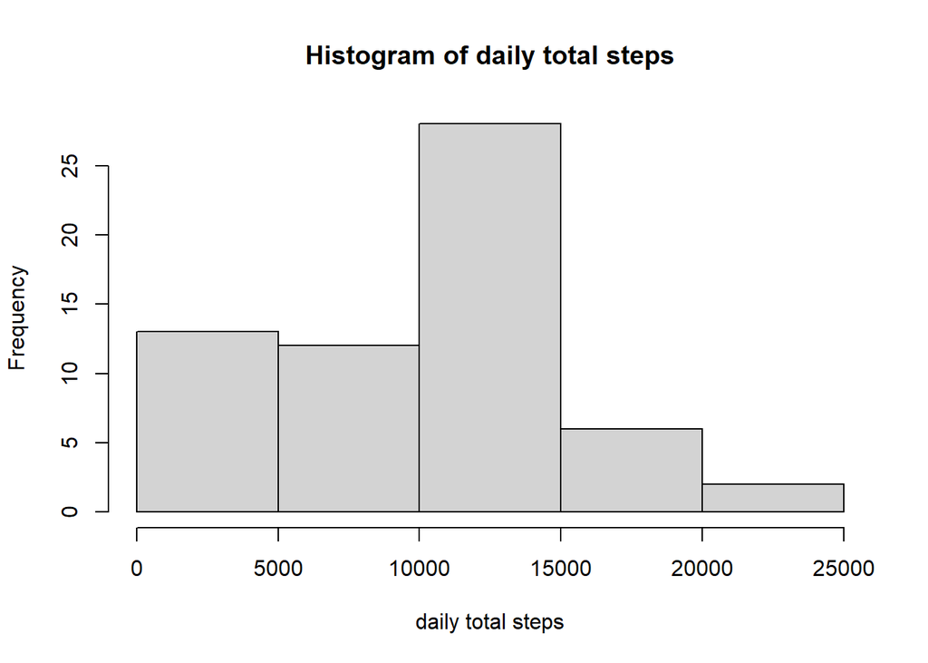

```r
hist(daySum$totalSteps,bins=20,xlab="daily total steps", main="Histogram of daily total steps")
```

## Mean and median number of steps taken each day

The mean and median number of steps taken daily are as below.

```r
mean_median= daySum %>% summarise(mean=mean(totalSteps,na.rm=T),median=median(totalSteps,na.rm=T))
mean_median
```

```
## # A tibble: 1 x 2
##    mean median
##   <dbl>  <int>
## 1 9354.  10395
```

[figure not shown]

```r
hist(dat$steps,bins=100,xlab="5-minute steps", main="Histogram of daily total steps before imputation")
```

```r
summary(dat$steps)
```

```
##    Min. 1st Qu.  Median    Mean 3rd Qu.    Max.    NA's
##    0.00    0.00    0.00   37.38   12.00  806.00    2304
```

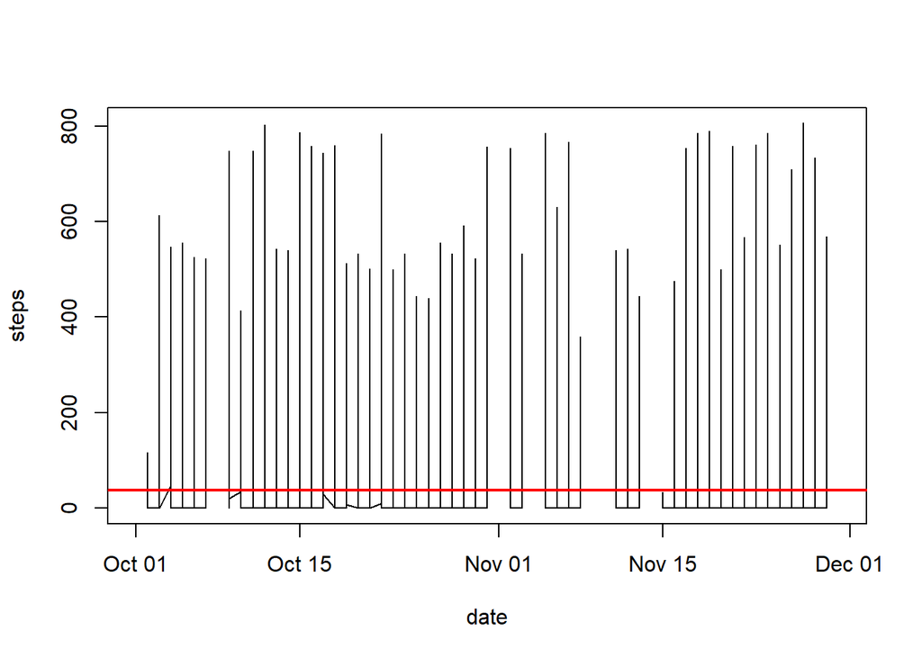

```r
mean0 = mean(dat$steps,na.rm=T)
plot(steps~date, data=dat,type="l")
abline(h=mean0, col= "red", lwd=2)
```

```r
dat[steps==max(steps,na.rm=T),]
```

```
##    steps       date interval
## 1:   806 2012-11-27      615
```

## describe and code a strategy for imputing missing data: using daily mean

```r
count_NA = dat %>% summarise(total=n(), countNA=sum(is.na(steps)),fraction=countNA/total)
count_NA
```

```
##   total countNA  fraction
## 1 17568    2304 0.1311475
```

```r
dayImputed = left_join(dat, daySum, by="date")
dayImputed$steps[which(is.na(dayImputed$steps))] = dayImputed$meanSteps[which(is.na(dayImputed$steps))]
head(dayImputed)
```

```
##    steps       date interval totalSteps meanSteps medianSteps
## 1:   NaN 2012-10-01        0          0       NaN          NA
## 2:   NaN 2012-10-01        5          0       NaN          NA
## 3:   NaN 2012-10-01       10          0       NaN          NA
## 4:   NaN 2012-10-01       15          0       NaN          NA
## 5:   NaN 2012-10-01       20          0       NaN          NA
## 6:   NaN 2012-10-01       25          0       NaN          NA
```

```r
#print(dayImputed,type="html")
```

[figure not shown]

```r
hist(dayImputed$steps,bins=100,xlab="5-minute steps", main="Histogram of daily total steps after imputation")
```

## Panel plot comparing the average number of steps taken per 5-minute interval across weekdays and weekends

```r
dayImputed$weekday = weekdays(dayImputed$date)
dayImputed$weekday_flag = with(dayImputed, ifelse(weekday%in%c("Saturday","Sunday"),"weekend","weekday"))
mean_5minInterval = dayImputed %>% group_by(weekday_flag,interval)%>% summarise(mean=mean(steps,na.rm=T))
```

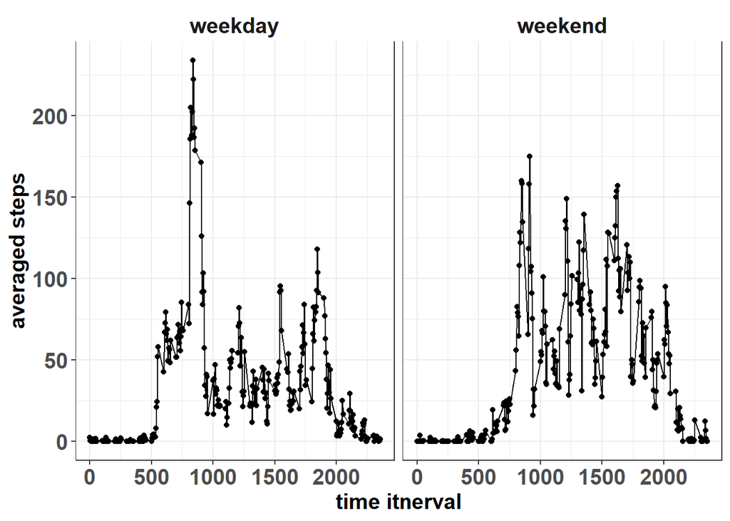

```r
p = ggplot(dat=mean_5minInterval,aes(x=interval,y=mean))+geom_point()+geom_line()+
    facet_wrap(~weekday_flag)
p = p + theme_bw()+labs(x="time itnerval",y="averaged steps")+ theme(axis.text=element_text(size=15,face="bold"),axis.title=element_text(size=15,face="bold"),                                         legend.box=NULL,legend.title=element_text(size=15,face="bold"),legend.text=element_text(size=15,face="bold"),                      strip.background=element_rect(fill="white",colour="white"),strip.text=element_text(size=15,face="bold"))
plot(p)
```

As shown in the plots, during weekdays, the peak activities is during the interval 750~1000 only. On weekends, the first activity peak also appeared around 750~1000, but then the activities continued high for some periods from 1000~1750 .